# ggplot2

Летняя школа // АнДан // 2021

А. Ангельгардт

5.08.2021

# Интродакшон

## Визуализация это зачем?

Вопрос не праздный, ибо что мы зря 100500 видов описательных статистик считали? Однако всё не так просто. Рассмотрим пример.

У нас есть датасет Квартет Анскомба[^1], который выглядит так (первые десять строк):

| id | dataset | x | y |
| --- | --- | --- | --- |
| 1 | 1 | 10 | 8.04 |
| 1 | 2 | 10 | 9.14 |
| 1 | 3 | 10 | 7.46 |
| 1 | 4 | 8 | 6.58 |
| 2 | 1 | 8 | 6.95 |
| 2 | 2 | 8 | 8.14 |
| 2 | 3 | 8 | 6.77 |
| 2 | 4 | 8 | 5.76 |
| 3 | 1 | 13 | 7.58 |
| 3 | 2 | 13 | 8.74 |

Если мы посчитаем описательные статистики в каждом субдатасете, то получим следующее:

| dataset | mean_x | mean_y | sd_x | sd_y | cor | n_obs |
| --- | --- | --- | --- | --- | --- | --- |
| 1 | 9 | 7.5 | 3.32 | 2.03 | 0.82 | 11 |
| 2 | 9 | 7.5 | 3.32 | 2.03 | 0.82 | 11 |
| 3 | 9 | 7.5 | 3.32 | 2.03 | 0.82 | 11 |
| 4 | 9 | 7.5 | 3.32 | 2.03 | 0.82 | 11 |

Ребят, тут всё идентично!

[figure not shown]

Однако давайте нарисуем:

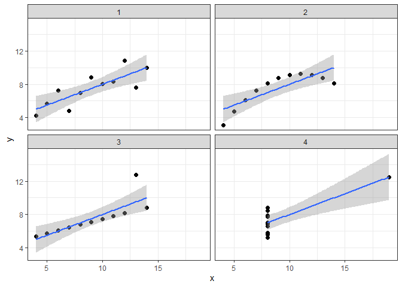

Што?

[figure not shown]

Мы обнаружили в явном виде, что несмотря на идентичные значения описательных статистик, паттерны в данных могут быть различны.

Чтобы впечатлиться окончательно, посмотрим на Datasaurus[^2]:

| dataset | mean_x | mean_y | sd_x | sd_y | cor | n_obs |
| --- | --- | --- | --- | --- | --- | --- |
| away | 54.3 | 47.8 | 16.8 | 26.9 | -0.1 | 142 |
| bullseye | 54.3 | 47.8 | 16.8 | 26.9 | -0.1 | 142 |
| circle | 54.3 | 47.8 | 16.8 | 26.9 | -0.1 | 142 |
| dino | 54.3 | 47.8 | 16.8 | 26.9 | -0.1 | 142 |
| dots | 54.3 | 47.8 | 16.8 | 26.9 | -0.1 | 142 |
| h_lines | 54.3 | 47.8 | 16.8 | 26.9 | -0.1 | 142 |
| high_lines | 54.3 | 47.8 | 16.8 | 26.9 | -0.1 | 142 |
| slant_down | 54.3 | 47.8 | 16.8 | 26.9 | -0.1 | 142 |
| slant_up | 54.3 | 47.8 | 16.8 | 26.9 | -0.1 | 142 |
| star | 54.3 | 47.8 | 16.8 | 26.9 | -0.1 | 142 |
| v_lines | 54.3 | 47.8 | 16.8 | 26.9 | -0.1 | 142 |
| wide_lines | 54.3 | 47.8 | 16.8 | 26.9 | -0.1 | 142 |
| x_shape | 54.3 | 47.8 | 16.8 | 26.9 | -0.1 | 142 |

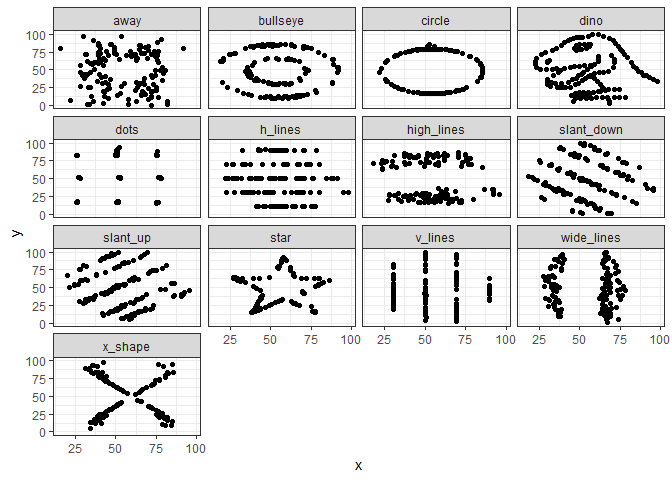

[figure not shown]

К чему это всё? К тому, что визуализация данных является жизненно необходимым этапом разведочного анализа. Она позволяет вам глубже и детальнее понять, что происходит в данных, и как это происходящее может отразиться на дальнейшем анализе.

## Философия A Layered Grammar of Graphics

Идея, воплолщенная в одном из мощнейших пакетов для визуализации `ggplot2`, восходит к работе [L. Wilkinson «The Grammar of Graphics»](https://www.springer.com/gp/book/9780387245447). Базируясь на идеях, изложенных в этой работе, Hadley Wickham разработал концепцию [Layered Grammar of Graphics](https://doi.org/10.1198/jcgs.2009.07098) и создал пакет для визуализации, ради которого мы все здесь собрались. Автором по этому пакету написана целая [книга](https://www.springer.com/gp/book/9780387981413), но мы сосредоточимся на основных смысловых и ключевых моментах, которые необходимы, чтобы сделать что-то крутое.

> Часто возникает вопрос: почему 2? Ответ примерно такой: был и первый ggplot, но попытка не задалась от слова совсем, и пришлось все переделать.

По своей сути график представляет собой сложную аппликацию из нескольких слоев. На каждом слое располагаются сходные по содержанию элементы. Начиная с самого первого — базового — и постепенно добавляя слой за слоем необходимые элементы, можно создавать сложные визуализации для отображения интересных закономерностей в данных.

После создания базового графика осуществляется настройка отдельных элементов по необходимости и в зависимости от требований издательства / преподавателя / научника / комиссии и т.д. И поскольку все элементы в определенной степени изолированы друг от друга, это открывает большие возможности кастомизации. Кроме того, чтобы оформить график в соответствии с конкретными требованиями, нет необходимости перерисовывать его целиком, так как содержательная часть графика независима от настроек внешнего облика. Все, что вам нужно — это добавить/удалить пару строк кода.

Но — хватит слов! Поехали уже рисовать уже!

# Экшон

## Пакеты

Для рисования нам понадобится пакет `ggplot2`. Если вы ранее его никогда не устанавливали, то воспользуйтесь такой командой:

```r
install.packages("ggplot2")
```

Проверить, установлен пакет или нет, можно так:

```r
"ggplot2" %in% installed.packages()
```

```
## [1] TRUE
```

После установки пакета его необходимо подключить к текущей сессии, чтобы мы могли пользоваться функциями, которые в нём лежат:

```r
library(ggplot2)
```

## Данные

Чтобы не ворочаться с загрузкой данных, воспользуемся для освоения мощностей ггплота встроенным в него датасетом `diamonds`:

```r
head(diamonds)
```

```
## # A tibble: 6 x 10
##   carat cut       color clarity depth table price     x     y     z
##   <dbl> <ord>     <ord> <ord>   <dbl> <dbl> <int> <dbl> <dbl> <dbl>
## 1  0.23 Ideal     E     SI2      61.5    55   326  3.95  3.98  2.43
## 2  0.21 Premium   E     SI1      59.8    61   326  3.89  3.84  2.31
## 3  0.23 Good      E     VS1      56.9    65   327  4.05  4.07  2.31
## 4  0.29 Premium   I     VS2      62.4    58   334  4.2   4.23  2.63
## 5  0.31 Good      J     SI2      63.3    58   335  4.34  4.35  2.75
## 6  0.24 Very Good J     VVS2     62.8    57   336  3.94  3.96  2.48
```

Описание датасета примерно такое:

| Variable | Description | Values |
| --- | --- | --- |
| price | price in US dollars | $326-$18,823 |
| carat | weight of the diamond | 0.2-5.01 |
| cut | quality of the cut | Fair, Good, Very Good, Premium, Ideal |
| color | diamond color | J (worst) to D (best) |
| clarity | measurement of how clear the diamond is | I1 (worst), SI2, SI1, VS2, VS1, VVS2, VVS1, IF (best) |
| x | length in mm | 0-10.74 |
| y | width in mm | 0-58.9 |
| z | depth in mm | 0-31.8 |
| depth | total depth percentage | 43-79 |
| table | width of top of diamond relative to widest point | 43-95 |

Но этот датасет очень большой — 53k наблюдений. Нам для освоения возможностей визуализации пока этого многовато. Давайте сделает случайную подвыборку из 1000 наблюдений:

```r
set.seed(34)
diamonds1000 <- diamonds %>% slice(sample(1:nrow(diamonds), 1000, replace = FALSE))
```